## Assignment 6

#### Due Sunday, March 26, 11:59 PM CT

### Preliminaries

- Directories
  - COURSE/homework/
  - COURSE/homework/hw06/
  - COURSE/data/
  - COURSE/scripts/
- Files
  - COURSE/homework/hw06/hw06.Rmd
  - COURSE/data/exoplanets-clean-through-2022.csv
  - COURSE/data/wordle.csv
  - COURSE/scripts/viridis.R

### Aims

- Practice strings and regular expressions

### Problems

Problems 1–4 are based on a data frame with the names of built-in R colors.

```r
df_colors = tibble(color = colors()) %>%
  mutate(index = row_number(), .before = color)
```

1. Create a data frame with the names of all colors whose names are exactly 7 characters long. Print a summary of this data frame with the number of colors and the first and last alphabetically in the list.

```r
q1 = df_colors %>% mutate(length=str_length(color)) %>% filter(length==7) %>% group_by(length) %>% mutate(number_of_colors=n()) %>% arrange(color)
q1 %>% ungroup() %>% filter(row_number()==1 | row_number()==n()) %>% select(color,number_of_colors)
```

```
## # A tibble: 2 × 2
##   color   number_of_colors
##   <chr>              <int>
## 1 bisque1               46
## 2 yellow4               46
```

2. How many of the previous color names contain no digits? Create a second data frame which eliminates the rows from your solution to the previous problem any color names which contain a digit. Print a summary of this data frame with the number of colors and the first and last alphabetically in the list.

```r
q2 = q1 %>% filter(!str_detect(color,"[:digit:]")) %>% group_by(length) %>% mutate(number_of_colors=n()) %>% arrange(color)
q2 %>% ungroup() %>% filter(row_number()==1 | row_number()==n())%>% select(color,number_of_colors)
```

```
## # A tibble: 2 × 2
##   color   number_of_colors
##   <chr>              <int>
## 1 darkred                8
## 2 thistle                8
```

3. Find all colors which contain consecutive letters “e”. Print a summary with a count of how many such colors there are and the first and last alphabetically.

```r
q3 = df_colors %>% filter(str_detect(color, "e{2,}"))
q3 %>% mutate(number_of_colors=n()) %>% filter(row_number()==1 | row_number()==n()) %>% select(color,number_of_colors)
```

```
## # A tibble: 2 × 2
##   color       number_of_colors
##   <chr>                  <int>
## 1 darkgreen                 60
## 2 yellowgreen               60
```

4. Find all color names which contain any consecutive identical letters. Create a data frame with these colors.
- Print the first ten rows of this data frame
- Tabulate how often each letter is used in a consecutive letter pair and print out this table arranged in descending order of the counts.
- Identify the three color names which have a distinct pair of consecutive identical letters. (These are the only color names which use the given letter pair.)

```r
q4 = df_colors %>% filter(str_detect(color, "([a-zA-Z])\\1"))
q4 %>% print(n=10)
```

```
## # A tibble: 104 × 2
##    index color
##    <int> <chr>
##  1    37 burlywood
##  2    38 burlywood1
##  3    39 burlywood2
##  4    40 burlywood3
##  5    41 burlywood4
##  6    81 darkgreen
##  7    83 darkkhaki
##  8    85 darkolivegreen
##  9    86 darkolivegreen1
## 10    87 darkolivegreen2
## # … with 94 more rows
```

```r
q4 %>% mutate(con_letter = str_extract(color,"([a-zA-Z])\\1")) %>% group_by(con_letter) %>% summarize(count = n()) %>% arrange(desc(count))
```

```
## # A tibble: 9 × 2
##   con_letter count
##   <chr>      <int>
## 1 ee            53
## 2 ll            17
## 3 ff            10
## 4 oo            10
## 5 gg             6
## 6 nn             5
## 7 cc             1
## 8 dd             1
## 9 kk             1
```

> moccasin, saddlebrown, darkkhaki
5. Load the exoplanet data set from the file `exoplanets-clean-through-2022.csv`. Create a new data frame by selecting only the columns `id` and `star`. Find and print all rows where the name in `star` does not match the string in `star` treated as a regular expression.
- What seems to be the common characteristic of such star names?

After identifying this characteristic, add a column to the `planets` data frame with the name `star_regex` which, when treated as a regular expression, does match the literal star name exactly. Such a regular expression should begin with `^` and end with `$`. Verify that each star name is matched by the regular expression.

```r
planets = read_csv("../../data/exoplanets-clean-through-2022.csv")
```

```r
planets %>% select(id,star) %>% filter(!str_detect(star, star)) %>% print(n=Inf)
```

```
## # A tibble: 30 × 2
##       id star
##    <dbl> <chr>
##  1    12 2MASS J04372171+2651014
##  2    16 2MASS J04414489+2301513
##  3    18 2MASS J19383260+4603591
##  4    19 2MASS J22362452+4751425
##  5    48 BD+03 2562
##  6    49 BD+14 4559
##  7    50 BD+15 2375
##  8    51 BD+15 2940
##  9    52 BD+20 2457
## 10    53 BD+20 2457
## 11    54 BD+20 274
## 12    55 BD+20 594
```

[output cut: 18 more lines]

```r
planets = planets %>% mutate(star_regex = str_c("^",star,"$")) %>% mutate(star_regex = str_replace_all(star_regex, "\\+", "\\\\+"))
planets %>% filter(!str_detect(star, star_regex))
```

```
## # A tibble: 0 × 8
## # … with 8 variables: id <dbl>, planet <chr>, star <chr>, method <chr>,
## #   year <dbl>, radius <dbl>, mass <dbl>, star_regex <chr>
```

> There are “+” inside star name
6. Most planets have a name equal to the star name followed by a space and a single lower case letter. Identify all planets for which this pattern is not true.
- Print the columns `id`, `planet`, `star`, and `year` for all planets in `planets` which do not fit this pattern.
- How many of the 5240 exoplanets do not follow the typical convention?

```r
planets %>% mutate(star_regex = str_c(str_sub(star_regex,1,-2)," [a-z]$")) %>% filter(!str_detect(planet,star_regex)) %>% select(id,planet,star,year)
```

```
## # A tibble: 48 × 4
##       id planet                       star                       year
##    <dbl> <chr>                        <chr>                     <dbl>
##  1    12 2M0437 b                     2MASS J04372171+2651014    2021
##  2    13 2MASS J01033563-5515561 AB b 2MASS J01033563-5515561 A  2013
##  3    75 CFHTWIR-Oph 98 b             CFHTWIR-Oph 98 A           2021
##  4    78 COCONUTS-2 b                 COCONUTS-2 A               2021
##  5   128 EPIC 201170410.02            EPIC 201170410             2020
##  6   133 EPIC 201615463 c             K2-166                     2019
##  7   134 EPIC 201754305 d             K2-16                      2019
##  8   135 EPIC 201757695.02            EPIC 201757695             2020
##  9   136 EPIC 201833600 c             K2-50                      2019
## 10   138 EPIC 205950854 c             K2-168                     2019
## # … with 38 more rows
```

> 48
7. For the planets whose names **do match** the pattern from the previous problem, create a table which counts the frequency of the last lower case letters in the planet name. Display this data with an effective graph.

```r
q7 = planets %>% mutate(star_regex = str_c(str_sub(star_regex,1,-2)," [a-z]$")) %>% filter(str_detect(planet,star_regex)) %>% select(planet,star) %>% mutate(last_letter = str_sub(planet,-1)) %>% group_by(last_letter) %>% summarize(n=n())
q7
```

```
## # A tibble: 7 × 2
##   last_letter     n
##   <chr>       <int>
## 1 b            3885
## 2 c             860
## 3 d             283
## 4 e             105
## 5 f              39
## 6 g              15
## 7 h               5
```

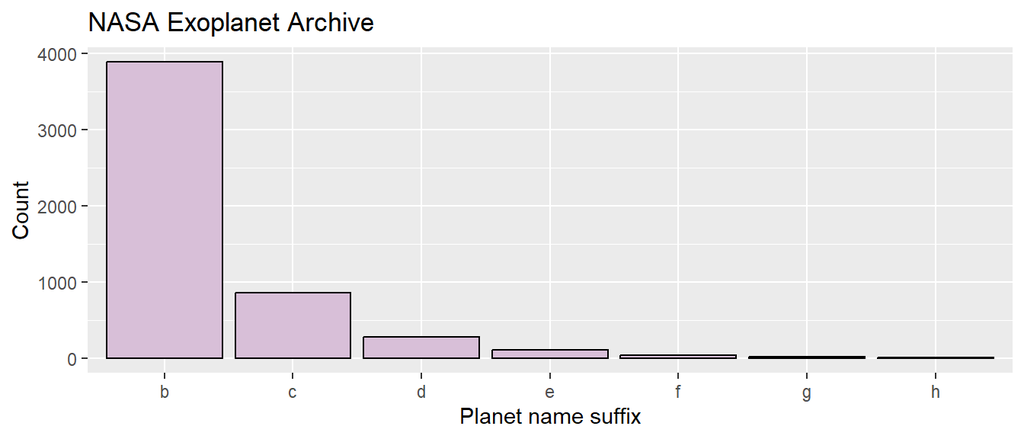

```r
ggplot(q7, aes(x=last_letter,y=n)) +
  geom_col(color="black", fill="thistle") +
  xlab("Planet name suffix") +
  ylab("Count") +
  ggtitle("NASA Exoplanet Archive")
```

8. The file `wordle_data.csv` contains the original solution list to the game Wordle. In the game, players attempt to identify a secret five-letter word by guessing a word and using the color-coded information returned. A green letter from the guess is in the correct location in the secret word. A yellow letter from the guess is in the secret word, but is not in the correct location. A gray letter is not in the word (unless a guess contains multiple copis of the same letter and at least one letter is colored and another is gray).

In a puzzle, the guess information is return for these first two guesses.

- SLATE returns the pattern Gray, Gray, Gray, Yellow, Gray
- COUNT returns the pattern Yellow, Green, Gray, Gray, Yellow

*(Note that the words in the data base have all lower case letters.)*

Find all possible solutions in `wrdl` which are consistent with the information given.

*Hint: you may find it easiest to pipe the word list through multiple `filter()` commands instead of trying to create a single regular expression which only matches all possible solutions. For example, you know the secret word contains at least one `T` and this letter is not in the 4th or 5th positions, at least one `C` which is not the first letter, and that the second letter is an `O`. You also know several letters which are not contained in the secret word.*

```r
wrdl = read_csv("../../data/wordle_data.csv") %>%
  filter(solution == TRUE) %>%
  select(word)

wrdl  %>% filter(!str_detect(word,"[slaeun]")) %>% filter(str_detect(str_sub(word,2,2),"o")) %>% filter(!str_detect(str_sub(word,4,4), "t")) %>% filter(!str_detect(str_sub(word,5,5), "t")) %>% filter(!str_detect(str_sub(word,1,1), "c")) %>% filter(str_detect(word, "t")) %>% filter(str_detect(word, "c"))
```

```
## # A tibble: 4 × 1
##   word
##   <chr>
## 1 botch
## 2 topic
## 3 torch
## 4 toxic
```